# Czynniki wpływające na czas rozwiązywania zadań z matematyki PISA 2015 - etap 1

Michał Ciach, Ola Paluszyńska

16 kwietnia 2017

```r
library(ggplot2)
library(moments) # obliczanie kurtozy i skośności rozkładów
library(MASS)
library(nortest) # testy na normalność rozkładu (Shapiro-Wilk nie działa dla wektorów dłuższych niż 5000)
library(car) # funkcja qqPlot rysuje QQ-plot z przedziałami ufności
library(lmtest)
library(gridExtra)
library(stringr)
setwd("~/UW/Modele_Liniowe_i_Mieszane/Projekt")
```

# Dane

Analizowane przez nas dane dotyczą czasu rozwiązywania zadań z matematyki PISA 2015. Struktura zbioru danych jest następująca:

```r
load("actionTimeScoreMath.rda")
task_data <- actionTimeScoreMath; rm(actionTimeScoreMath)
names(task_data)[names(task_data) == "T"] <- "time"
str(task_data)
```

```
## 'data.frame':    3894248 obs. of  10 variables:
##  $ CNT       : Factor w/ 73 levels "ALB      ","ARE      ",..: 3 3 3 3 3 3 3 3 3 3 ...
##  $ CNTSCHID  : num  3600428 3600428 3600428 3600428 3600428 ...
##  $ CNTSTUID  : num  3600001 3600001 3600001 3600001 3600001 ...
##  $ BOOKID    : Factor w/ 64 levels "31","32","33",..: 14 14 14 14 14 14 14 14 14 14 ...
##  $ item_short: chr  "M496Q02" "M423Q01" "M603Q01" "M571Q01" ...
##  $ subject   : Factor w/ 3 levels "CM","CR","DR": 1 1 1 1 1 1 1 1 1 1 ...
##  $ A         : num  12 2 5 2 4 6 8 7 5 3 ...
##  $ S         : Factor w/ 3 levels "Full credit",..: 1 1 1 1 1 1 1 1 1 1 ...
##  $ time      : num  79425 14559 88506 104413 60526 ...
##  $ position  : Factor w/ 5 levels "-1","1","2","3",..: 4 4 4 4 4 4 5 5 5 5 ...
```

```r
head(task_data)
```

```
##         CNT CNTSCHID CNTSTUID BOOKID item_short subject  A           S
## 1 AUS        3600428  3600001     44    M496Q02      CM 12 Full credit
## 2 AUS        3600428  3600001     44    M423Q01      CM  2 Full credit
## 3 AUS        3600428  3600001     44    M603Q01      CM  5 Full credit
## 4 AUS        3600428  3600001     44    M571Q01      CM  2 Full credit
## 5 AUS        3600428  3600001     44    M564Q01      CM  4 Full credit
## 6 AUS        3600428  3600001     44    M564Q02      CM  6 Full credit
##     time position
## 1  79425        3
## 2  14559        3
## 3  88506        3
## 4 104413        3
## 5  60526        3
## 6 112691        3
```

Zmienne oznaczają kolejno: kraj (`CNT`), id szkoły (`CNTSCHID`), id studenta (`CNTSTUID`), id kwestionariusza (`BOOKID`), kod zadania (`item_short`), przedmiot (`subject`, CM to matematyka, CR to czytanie, a DR to nauki przyrodnicze), liczbę kliknięć w trakcie rozwiązywania zadania (`A`), punkty za zadanie (`S`), czas rozwiązywania zadania (`time`) oraz pozycja zadania w kwestionariuszu (`position`).

Kod zadania zawiera dwie składowe: id zadania oraz numer podpunktu (Q01, Q02, Q03, Q04 oraz Q05). Na potrzeby analizy rozdzielimy te dwie składowe tworząc dwie nowe zmienne (`task` to id zadania i `Q` to numer podpunktu) żeby umożliwić analizowanie ich oddzielnie:

```r
task_data$task <- gsub("Q\\d+", "", task_data$item_short)
task_data$task <- as.factor(task_data$task)
table(task_data$task)
```

```
##
##   M00G   M00K   M033   M034   M155   M192   M273   M305   M406   M408
##  55537  54494  55959  53629 222837  55423  56029  55761 110246  55939
##   M411   M420   M423   M442   M446   M447   M462   M464   M474   M496
## 110299  55857  55549  54416 111350  56100  53916  54717  55928 111348
##   M559   M564   M571   M603   M800   M803   M828   M905   M906   M909
##  55470 108190  54448  54708  54366  54820 110190  87943 109914 174823
##   M915   M919   M936   M939   M943   M948   M949   M953   M954   M955
## 114833  87681  24258  23131  87401  36782 174071 129739 131598 165661
##   M961   M967   M982   M992   M998
##  35517  22691 224219 167414 109046
```

```r
task_data$Q <- gsub("M\\d+\\D?Q", "Q", task_data$item_short)
task_data$Q <- as.factor(task_data$Q)
table(task_data$Q)
```

```
##
##     Q01     Q02     Q03     Q04     Q05
## 1945288 1212249  472204  252799   11708
```

Liczba zadań w zbiorze danych wynosi 45. Macierz kontyngencji zadanie/podpunkt:

```r
table(task_data$task, task_data$Q)
```

```
##
##          Q01   Q02   Q03   Q04   Q05
##   M00G 55537     0     0     0     0
##   M00K     0 54494     0     0     0
##   M033 55959     0     0     0     0
##   M034 53629     0     0     0     0
##   M155 55802 55823 55667 55545     0
##   M192 55423     0     0     0     0
##   M273 56029     0     0     0     0
##   M305 55761     0     0     0     0
##   M406 55196 55050     0     0     0
##   M408 55939     0     0     0     0
##   M411 55205 55094     0     0     0
##   M420 55857     0     0     0     0
##   M423 55549     0     0     0     0
##   M442     0 54416     0     0     0
##   M446 55735 55615     0     0     0
##   M447 56100     0     0     0     0
##   M462 53916     0     0     0     0
##   M464 54717     0     0     0     0
##   M474 55928     0     0     0     0
##   M496 55709 55639     0     0     0
##   M559 55470     0     0     0     0
##   M564 54187 54003     0     0     0
##   M571 54448     0     0     0     0
##   M603 54708     0     0     0     0
##   M800 54366     0     0     0     0
##   M803 54820     0     0     0     0
##   M828     0 55192 54998     0     0
##   M905 43974 43969     0     0     0
##   M906 55090 54824     0     0     0
##   M909 58313 58290 58220     0     0
##   M915 57503 57330     0     0     0
##   M919 43841 43840     0     0     0
##   M936 12152 12106     0     0     0
##   M939 11583 11548     0     0     0
##   M943 43740 43661     0     0     0
##   M948 12294 12265 12223     0     0
##   M949 58109 58075 57887     0     0
##   M953     0 43437 43306 42996     0
##   M954 43895 43878     0 43825     0
##   M955 55416 55251 54994     0     0
##   M961     0 11937 11872     0 11708
##   M967 11383     0 11308     0     0
##   M982 56110 56079 56041 55989     0
##   M992 55895 55831 55688     0     0
##   M998     0 54602     0 54444     0
```

Jak widać, nie wszystkie zadania mają wszystkie podpunkty. W szczególności niektóre zadania nie mają podpunktu piewrszego. Dlatego wprowadzimy dodatkową numerację podpunktów, która odzwierciedla ich kolejność (np. jeśli w zadaniu nie było podpunktu Q01 to w nowej zmiennej będzie zamiast podpunktu Q02 w starej wersji). Pozwstałą w ten sposób zmienną nazwiemy `Q.nb`.

```r
non.empty <- apply(table(task_data$task, task_data$Q), 1, function(x) ifelse(x == 0, 0, 1))
question.id <- apply(non.empty, 2, function(x) ifelse(x==0, 0, cumsum(x)))
task_data$Q.nb <- apply(task_data, 1, function(x) question.id[x["Q"], x["task"]])
task_data$Q.nb <- as.factor(task_data$Q.nb)
# head(task_data[task_data$task=="M00K", ])
```

Ponieważ naszą zmienną objaśnianą jest czas rozwiązywania zadania, usuniemy ze zbioru danych wszystkie obserwacje, dla których brakuje wartości tej zmiennej (gdybyśmy tego nie zrobili, to musielibyśmy to robić np. przy liczeniu wszelkich statystyk w dalszej części analizy).

```r
task_data <- task_data[!is.na(task_data$time),]
```

Następnie przytniemy wartości zmiennej `time` przekraczające 500000 (zmienna ta jest w milisekundach, czyli patrzymy na wartości przekraczające 8 i 1/3 minuty), gdyż takie czasy pojawiają się prawdopodobnie ze względu na problemy przy zbieraniu danych (np. uczeń wyszedł do toalety lub nie wyłączył komputera).

```r
task_data[task_data$time > 500000, "time"] <- 500000
```

W celu przyspieszenia obliczeń będziemy pracować tylko na części naszego zbioru danych, do której wybraliśmy co czwartą szkołę z każdego kraju (kod wybierający te szkoły znajduje się w części 2 pracy):

```r
chosen_schools <- read.csv("Chosen_schools.csv")
sample_data <- task_data[task_data$CNTSCHID %in% chosen_schools$x, ]
rm(chosen_schools)
save(sample_data, file = "sample_data.rda")
```

# Model liniowy zbudowany na cechach zadania

## Analizowane zmienne

### Kodowanie zmiennych objaśniających

Zanim zbudujemy model liniowy powinniśmy zastanowić się, w jaki sposób włączyć do niego nasze trzy jakościowe zmienne objaśniające: zadanie (`task`), podpunkt (`Q`) oraz pozycja w kwestionariuszu (`position`). Domyślnie będziemy używać kodowania referencyjnego, a więc dla każdej ze zmiennych musimy wybrać kategorię bazową. Ponieważ kategoria ta powinna być możliwie liczna (w przeciwnym razie oszacowania parametrów mogą być nieistotne ze względu na to, że stanowią one o różnicy względem kategorii bazowej), w przypadku zadania wybierzemy kategorię występującą najczęściej, czyli M982, natomiast w przypadku podpunktu oraz pozycji w kwestionariuszu wybierzemy podpunkt i pozycję pierwszą, które wydają się być naturalnymi punktami odniesienia (przy okazji są to kategorie najliczniejsze).

```r
# Zmieniamy kategorię, która jest pierwsza czyli będzie brana jako bazowa
task_data <- within(task_data, position <- relevel(position, ref = 2))
task_data <- within(task_data, task <- relevel(task, ref = 43))
sample_data <- within(sample_data, position <- relevel(position, ref = 2))
sample_data <- within(sample_data, task <- relevel(task, ref = 43))
```

### Rozkład zmiennej objaśnianej

Jednym z założeń modelu liniowego jest normalność rozkładu reszt. Problem ze spełnieniem tego założenia zwykle rozwiązuje się stosując pewną transformację zmiennej objaśnianej przed docelowym modelowaniem, co rozważymy w tej części analizy.

### Rozkład w całym zbiorze a rozkład w podpróbce

```r
rbind(Full = quantile(task_data$time, probs = c(0.25, 0.5, 0.75, 0.9, 0.98, 1)),
Sample = quantile(sample_data$time, probs = c(0.25, 0.5, 0.75, 0.9, 0.98, 1)))
```

```
##          25%   50%      75%      90%      98%  100%
## Full   46562 77122 123959.0 190588.0 333239.2 5e+05
## Sample 46597 77210 124060.8 190623.4 333238.7 5e+05
```

Poniżej przedstawiamy rozkład czasu rozwiązywania zadania w próbce i w całej populacji – jednocześnie prezentujemy gęstość rozkładu normalnego o średniej i wariancji odpowiadających statystykom naszej zmiennej.

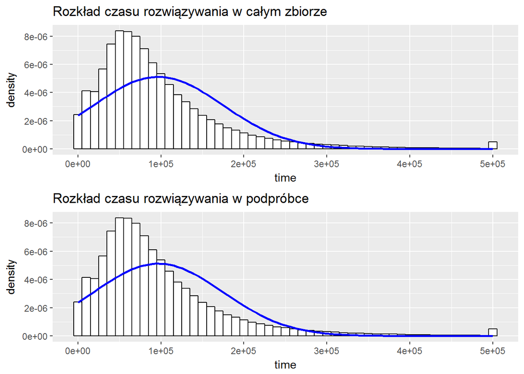

```r
mean.time <- mean(task_data$time); sd.time <- sd(task_data$time)
sample.mean <- mean(sample_data$time); sample.sd <- sd(sample_data$time)
full.plot <- ggplot(task_data, aes(x = time)) + geom_histogram(aes(y=..density..), binwidth = 10000, color = "black", fill = "white") + stat_function(fun = dnorm, args = list(mean = mean.time, sd = sd.time), color = "blue", size = 1) + ggtitle("Rozkład czasu rozwiązywania w całym zbiorze")
sample.plot <- ggplot(sample_data, aes(x = time)) + geom_histogram(aes(y=..density..), binwidth = 10000, color = "black", fill = "white") + stat_function(fun = dnorm, args = list(mean = sample.mean, sd = sample.sd), color = "blue", size = 1) + ggtitle("Rozkład czasu rozwiązywania w podpróbce")
grid.arrange(full.plot, sample.plot)
```

```r
rm(full.plot, sample.plot, task_data)
```

### Reszty modelu wyjściowego

Teraz wyznaczymy reszty modelu liniowego, który będzie punktem wyjścia w naszej analizie i przedstawimy je na wykresie porównując z rozkładem normalnym:

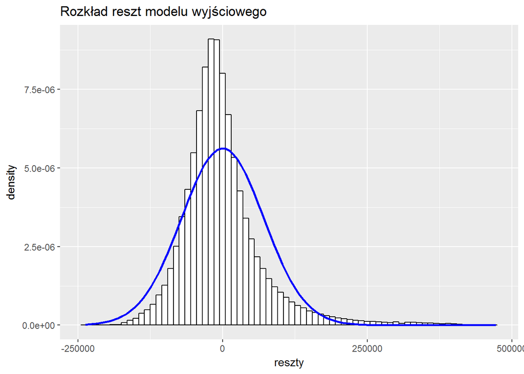

```r
modelTaskQPosition <- lm(time ~ task + task/Q.nb + position, data = sample_data)
ggplot(data.frame(reszty = modelTaskQPosition$residuals), aes(x = reszty)) + geom_histogram(aes(y=..density..), binwidth = 10000, color = "black", fill = "white") + stat_function(fun = dnorm, args = list(mean = mean(modelTaskQPosition$residuals), sd = sd(modelTaskQPosition$residuals)), color = "blue", size = 1) + ggtitle("Rozkład reszt modelu wyjściowego")
```

Na powyższym wykresie widać wyraźną rozbieżność rozkładu reszt względem rozkładu normalnego. Jest on silnie prawoskośny (współczynnik skośności wynosi 1.7078219, w rozkładzie normalnym jest to 0) i spiczasty (kurtoza wynosi 8.7466575, w rozkładzie normalnym jest to 3), zatem przed rozpoczęciem modelu powinniśmy wykonać odpowiednią transformację zmiennej objaśnianej. Rozpatrzymy dwa rodzaje transformacji: Boxa-Coxa oraz logarytmiczną z przesunięciem.

### Transformacja Boxa-Coxa

Poniżej przedstawiamy wykres log-wiarygodności modelu w zależności od zastosowanej transformacji Boxa-Coxa.

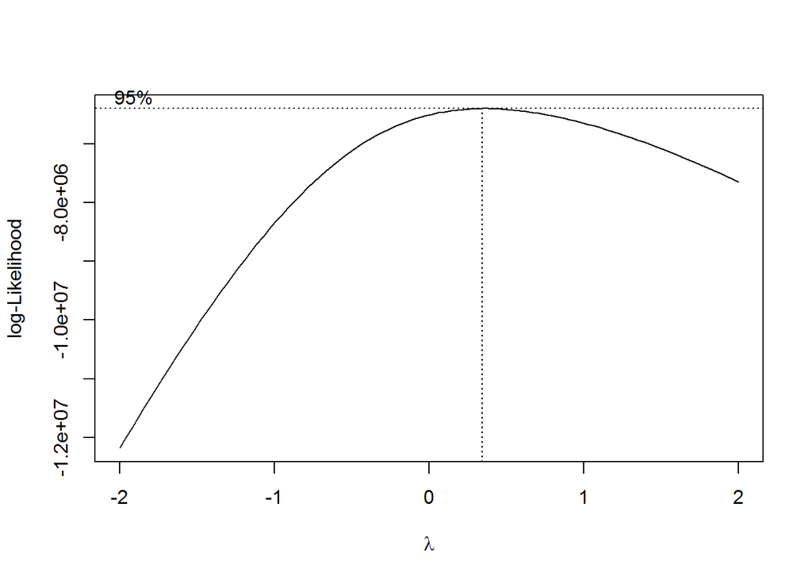

```r
bc <- boxcox(modelTaskQPosition, plotit = TRUE)
```

```r
wykladnik <- bc$x[which.max(bc$y)] # optymalny wykładnik
```

Optymalny wykładnik (spośród rozpatrywanej siatki wykładników) dla tej transformacji wynosi 0.3434343, przy czym wykładnik ten zależy od postaci modelu, więc w przypadku problemu z diagnostyką innych wersji modelu na dalszym etapie analizy będziemy musieli powrócić do tej kwestii.

Na poniższym wykresie prezentujemy rozkład reszt modelu po zastosowaniu tej transformacji oraz gęstość rozkładu normalnego o parametrach równych statystykom tego rozkładu.

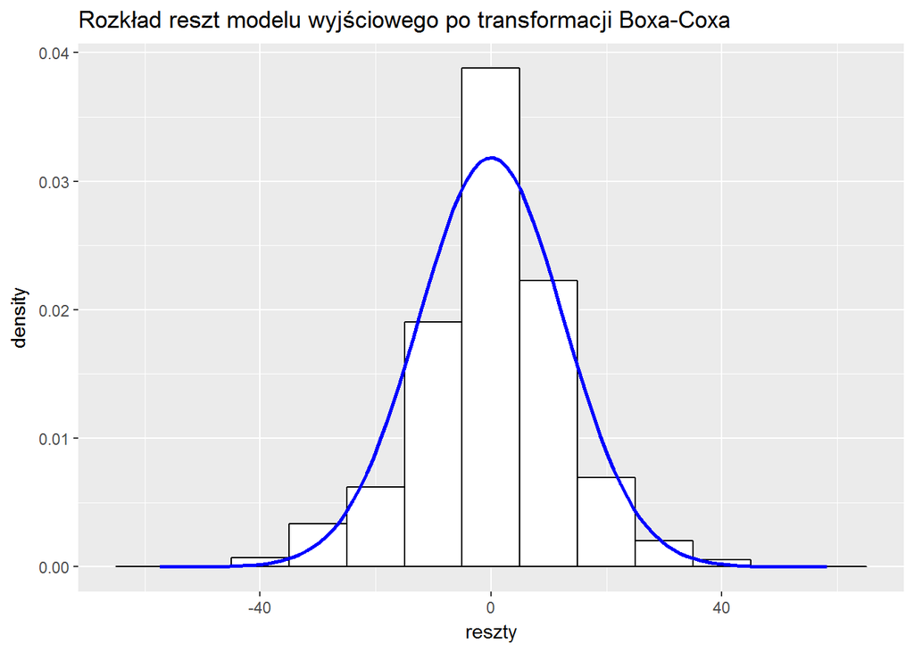

```r
modelTaskQPosition_bc <- lm(time^wykladnik ~ task + task/Q.nb + position, data = sample_data)
ggplot(data.frame(reszty = modelTaskQPosition_bc$residuals), aes(x = reszty)) + geom_histogram(aes(y=..density..), binwidth = 10, color = "black", fill = "white") + stat_function(fun = dnorm, args = list(mean = mean(modelTaskQPosition_bc$residuals), sd = sd(modelTaskQPosition_bc$residuals)), color = "blue", size = 1) + ggtitle("Rozkład reszt modelu wyjściowego po transformacji Boxa-Coxa")
```

Jak widać, dopasowanie rozkładu normalnego do rozkładu naszej zmiennej po transformacji jest znacznie lepsze niż wcześniej. Skośność jest bliska zera: -0.1843574, natomiast kurtoza wynosi 4.03837, czyli nieznacznie więcej niż powinna – nawet tak niewielka rozbieżność może prowadzić do odrzucenia hipotezy zerowej testu na normalność rozkładu:

```r
ad.test(modelTaskQPosition_bc$residuals) # test Andersona Darlinga
```

```
##
##  Anderson-Darling normality test
##
## data:  modelTaskQPosition_bc$residuals
## A = 5441.2, p-value < 2.2e-16
```

```r
rm(modelTaskQPosition_bc)
```

Faktycznie odrzucamy hipotezę zerową, jednak warto zaznaczyć, że testy normalności są bardzo restrykcyjne i zwykle prowadzą do odrzucenia hipotezy o normalności rozkładu, szczególnie przy tak dużej próbie. Z tego względu przy ocenie normalności rozkładu będziemy bazować bardziej na porównaniu wykresów rozkładu oraz wykresów typu QQ.